# Varsayım Analizi Ödevi

Ege yenil, Şeref Can Memiş, Emine Nur Kara, İrem Küçükterzi, Kayra Kalkan

2025-01-05

# Petrol Consumption Veri modelleme ve varsayım analizi

Öncelikle gerekli kütüphaneleri aktif hale getirelim

```r
library(mice)
library(caret)
library(lmtest)
library(faraway)
library(ggplot2)
library(dplyr)
library(broom)
library(ggpubr)
library(ISLR)
```

## Şimdi Veriyi import edelim ve veri hakkında ön bilgi edinelim

```r
petrol<-read.csv("C:/Users/egeye/Downloads/petrol_consumption.csv")
names(petrol)
```

```
## [1] "Petrol_tax"                   "Average_income"
## [3] "Paved_Highways"               "Population_Driver_licence..."
## [5] "Petrol_Consumption"
```

```r
head(petrol)
```

```
##   Petrol_tax Average_income Paved_Highways Population_Driver_licence...
## 1        9.0           3571           1976                        0.525
## 2        9.0           4092           1250                        0.572
## 3        9.0           3865           1586                        0.580
## 4        7.5           4870           2351                        0.529
## 5        8.0           4399            431                        0.544
## 6       10.0           5342           1333                        0.571
##   Petrol_Consumption
## 1                541
## 2                524
## 3                561
## 4                414
## 5                410
## 6                457
```

```r
str(petrol)
```

```
## 'data.frame':    48 obs. of  5 variables:
##  $ Petrol_tax                  : num  9 9 9 7.5 8 10 8 8 8 7 ...
##  $ Average_income              : int  3571 4092 3865 4870 4399 5342 5319 5126 4447 4512 ...
##  $ Paved_Highways              : int  1976 1250 1586 2351 431 1333 11868 2138 8577 8507 ...
##  $ Population_Driver_licence...: num  0.525 0.572 0.58 0.529 0.544 0.571 0.451 0.553 0.529 0.552 ...
##  $ Petrol_Consumption          : int  541 524 561 414 410 457 344 467 464 498 ...
```

```r
nrow(petrol);ncol(petrol)
```

```
## [1] 48
```

```
## [1] 5
```

Bir de değişkenler arasındaki korelasyonları inceleyelip fikir edinelim;

```r
cor(petrol)
```

```
##                               Petrol_tax Average_income Paved_Highways
## Petrol_tax                    1.00000000     0.01266516    -0.52213014
## Average_income                0.01266516     1.00000000     0.05016279
## Paved_Highways               -0.52213014     0.05016279     1.00000000
## Population_Driver_licence... -0.28803717     0.15707008    -0.06412950
## Petrol_Consumption           -0.45128028    -0.24486207     0.01904194
##                              Population_Driver_licence... Petrol_Consumption
## Petrol_tax                                     -0.2880372        -0.45128028
## Average_income                                  0.1570701        -0.24486207
## Paved_Highways                                 -0.0641295         0.01904194
## Population_Driver_licence...                    1.0000000         0.69896542
## Petrol_Consumption                              0.6989654         1.00000000
```

## Missing Kontrolü

```r
md.pattern(petrol)
```

```
##  /\     /\
## {  `---'  }
## {  O   O  }
## ==>  V <==  No need for mice. This data set is completely observed.
##  \  \|/  /
##   `-----'
```

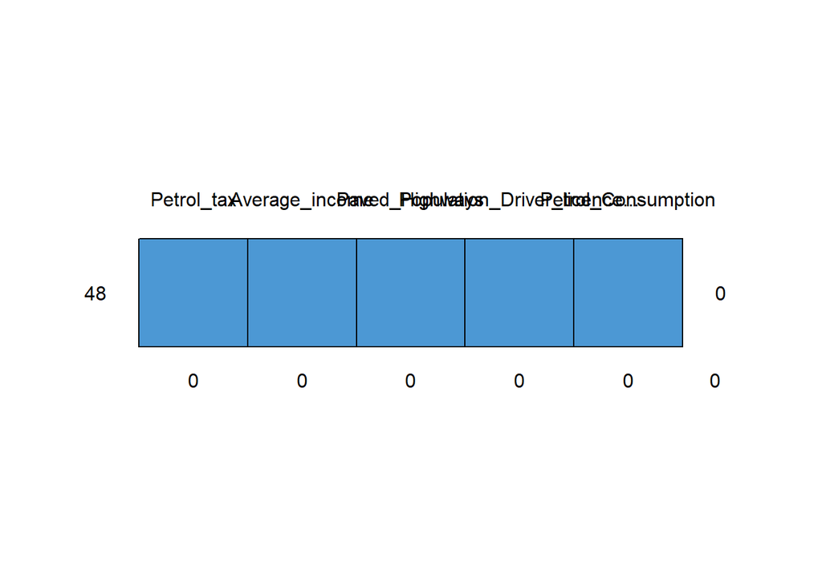

```
##    Petrol_tax Average_income Paved_Highways Population_Driver_licence...
## 48          1              1              1                            1
##             0              0              0                            0
##    Petrol_Consumption
## 48                  1 0
##                     0 0
```

Veri içerisinde herhangi bir missing değer gözükmüyor.

# Model Oluşturma

## öncelikle veriyi Train-Test olarak parçalayalım

```r
set.seed(100)
indx<- sample(1:nrow(petrol),size = 0.8*nrow(petrol))
train<- petrol[indx,]
test<- petrol[-indx,]
```

## Veriyi parçaladık. Şimdi Birkaç farklı şekilde model oluşturalım ve bunları inceleyelim

```r
names(petrol)
```

```
## [1] "Petrol_tax"                   "Average_income"
## [3] "Paved_Highways"               "Population_Driver_licence..."
## [5] "Petrol_Consumption"
```

```r
model1<- lm(Petrol_Consumption~.,data = train)
summary(model1)
```

```
##
## Call:
## lm(formula = Petrol_Consumption ~ ., data = train)
##
## Residuals:
##     Min      1Q  Median      3Q     Max
## -89.296 -45.614  -5.436  38.918 220.666
##
## Coefficients:
##                                Estimate Std. Error t value Pr(>|t|)
## (Intercept)                   4.334e+02  2.004e+02   2.163  0.03786 *
## Petrol_tax                   -3.675e+01  1.401e+01  -2.623  0.01308 *
## Average_income               -7.339e-02  2.013e-02  -3.645  0.00091 ***
## Paved_Highways               -3.124e-03  3.731e-03  -0.837  0.40847
## Population_Driver_licence...  1.343e+03  2.043e+02   6.571 1.81e-07 ***
## ---
## Signif. codes:  0 '***' 0.001 '**' 0.01 '*' 0.05 '.' 0.1 ' ' 1
##
## Residual standard error: 67.36 on 33 degrees of freedom
## Multiple R-squared:  0.7226, Adjusted R-squared:  0.689
## F-statistic: 21.49 on 4 and 33 DF,  p-value: 8.35e-09
```

Öncelikle Modelin p-value değerine baktığımız zaman 0.05’den küçük yani modelimiz anlamlıdır. Bunun yanında $R^2$=0.689 olarak gelmiştir. Değişkenleri incelediğimiz zaman **Paved_Highways** değişkeni anlamsız gelmiştir. Bunun dışındaki diğer bağımsız değişkenler modelde anlamlıdır.

Paved_Highways değişkenini kullanmadan bir model kuralım;

```r
model2<-lm(Petrol_Consumption~.-Paved_Highways,data = train)
summary(model2)
```

```
##
## Call:
## lm(formula = Petrol_Consumption ~ . - Paved_Highways, data = train)
##
## Residuals:
##     Min      1Q  Median      3Q     Max
## -92.463 -43.901  -7.687  41.126 225.199
##
## Coefficients:
##                                Estimate Std. Error t value Pr(>|t|)
## (Intercept)                   344.34188  169.02129   2.037 0.049467 *
## Petrol_tax                    -29.97473   11.38607  -2.633 0.012654 *
## Average_income                 -0.07546    0.01989  -3.794 0.000583 ***
## Population_Driver_licence... 1393.10986  194.32673   7.169 2.73e-08 ***
## ---
## Signif. codes:  0 '***' 0.001 '**' 0.01 '*' 0.05 '.' 0.1 ' ' 1
##
## Residual standard error: 67.06 on 34 degrees of freedom
## Multiple R-squared:  0.7167, Adjusted R-squared:  0.6918
## F-statistic: 28.68 on 3 and 34 DF,  p-value: 1.979e-09
```

model2 yi incelediğimiz zaman Modelin p-value değeri yine 0.05’den küçüktür yani model anlamlıdır. $R^2$=0.6918 olmuştur yani az da olsa artış meydana gelmiştir. Bunun dışında modeldeki bağımsız değişkenleri incelediğimizde bütün değişkenler modelde anlamlıdır.

Bir de stepwise regresyon yöntemi ile model kuralım. Bakalım nasıl bir model elde edeceğiz

```r
model3<- step(lm(Petrol_Consumption~1,data = train),direction = "both",
              scope = ~Petrol_tax+Average_income+Paved_Highways+Population_Driver_licence...)
```

```
## Start:  AIC=365.33
## Petrol_Consumption ~ 1
##
##                                Df Sum of Sq    RSS    AIC
## + Population_Driver_licence...  1    279859 259961 339.57
## + Petrol_tax                    1    123206 416614 357.49
## + Average_income                1     41278 498542 364.31
## <none>                                      539820 365.33
## + Paved_Highways                1        24 539796 367.33
##
## Step:  AIC=339.57
## Petrol_Consumption ~ Population_Driver_licence...
##
##                                Df Sum of Sq    RSS    AIC
## + Average_income                1     75887 184075 328.45
## + Petrol_tax                    1     42333 217628 334.81
## <none>                                      259961 339.57
## + Paved_Highways                1      2065 257897 341.26
## - Population_Driver_licence...  1    279859 539820 365.33
##
## Step:  AIC=328.45
## Petrol_Consumption ~ Population_Driver_licence... + Average_income
##
##                                Df Sum of Sq    RSS    AIC
## + Petrol_tax                    1     31168 152907 323.40
## <none>                                      184075 328.45
## + Paved_Highways                1      3127 180948 329.80
## - Average_income                1     75887 259961 339.57
## - Population_Driver_licence...  1    314468 498542 364.31
##
## Step:  AIC=323.4
## Petrol_Consumption ~ Population_Driver_licence... + Average_income +
##     Petrol_tax
##
##                                Df Sum of Sq    RSS    AIC
## <none>                                      152907 323.40
## + Paved_Highways                1      3181 149726 324.60
## - Petrol_tax                    1     31168 184075 328.45
## - Average_income                1     64722 217628 334.81
## - Population_Driver_licence...  1    231128 384035 356.39
```

```r
summary(model3)
```

```
##
## Call:
## lm(formula = Petrol_Consumption ~ Population_Driver_licence... +
##     Average_income + Petrol_tax, data = train)
##
## Residuals:
##     Min      1Q  Median      3Q     Max
## -92.463 -43.901  -7.687  41.126 225.199
##
## Coefficients:
##                                Estimate Std. Error t value Pr(>|t|)
## (Intercept)                   344.34188  169.02129   2.037 0.049467 *
## Population_Driver_licence... 1393.10986  194.32673   7.169 2.73e-08 ***
## Average_income                 -0.07546    0.01989  -3.794 0.000583 ***
## Petrol_tax                    -29.97473   11.38607  -2.633 0.012654 *
## ---
## Signif. codes:  0 '***' 0.001 '**' 0.01 '*' 0.05 '.' 0.1 ' ' 1
##
## Residual standard error: 67.06 on 34 degrees of freedom
## Multiple R-squared:  0.7167, Adjusted R-squared:  0.6918
## F-statistic: 28.68 on 3 and 34 DF,  p-value: 1.979e-09
```

model3’ü yani stepwise ile kurduğumuz modeli incelediğimizde, model2 deki gibi sadece Paved_Highways değişkenini çıkartarak model kurmuştur. Yani aslında model2 ile aynı model elde edilmiştir.

Bu Durumda elimizde karşılaştırabileceğimiz 2 farklı model mevcut.

## Bu modelleri test verisi üzerinden karşılaştıralım

```r
prediction1<- predict(model1,test)
prediction2<- predict(model2,test)
```

```r
karsilastirma <- data.frame("R2"=c(R2(prediction1, test$Petrol_Consumption),R2(prediction2, test$Petrol_Consumption)),
                            "RMSE"=c(RMSE(prediction1, test$Petrol_Consumption),RMSE(prediction2, test$Petrol_Consumption)),
                            "MAE"=c(MAE(prediction1, test$Petrol_Consumption),MAE(prediction2, test$Petrol_Consumption)),
                            "AIC"=c(AIC(model1, k = 6),AIC(model2, k = 5)),
                            "BIC"=c(BIC(model1),BIC(model2)))
row.names(karsilastirma)<- c("model1","model2")
karsilastirma
```

```
##               R2     RMSE      MAE      AIC      BIC
## model1 0.5926828 68.63620 58.02502 458.4404 444.2659
## model2 0.6487435 68.07854 58.55065 448.2392 441.4271
```

Karşılaştırma metriklerini incelediğimiz zaman MAE dışındaki bütün metrikler model2’nin yani Paved_Highways değişkeninin çıkarıldığı modelin daha iyi olduğunu gösteriyor.

# Model Varsayım Kontrolleri

## Değişen Varyans Durumu

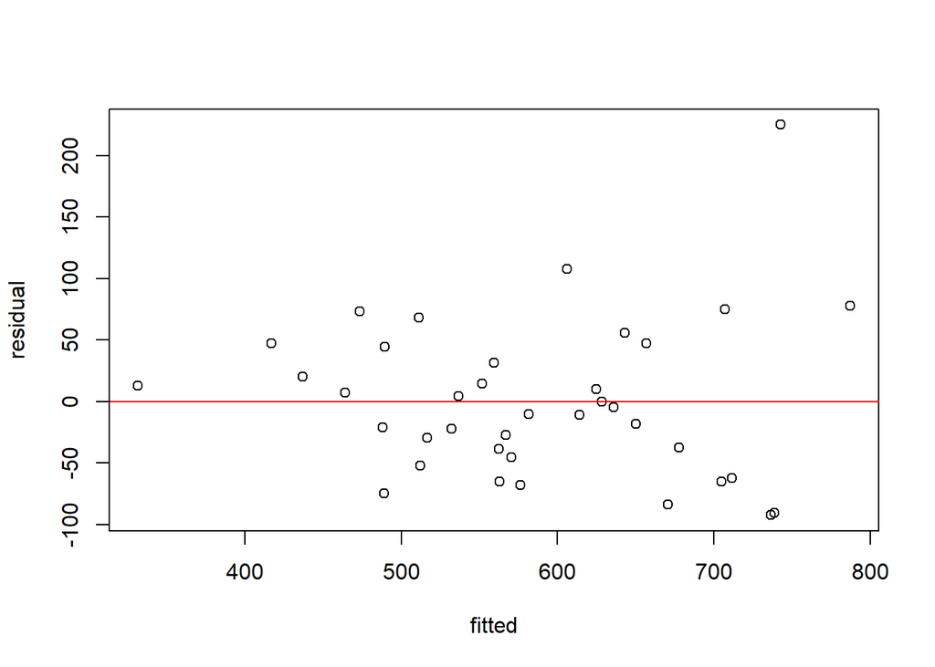

```r
plot(model2$fitted.values,model2$residuals,
     xlab = "fitted",ylab = "residual")
abline(h=0,col="red")
```

Bir de matematiksel olarak değişen varyans durumunu kontrol etmek için Breusch-Pagan testini kullanalım;

```r
bptest(model2,data=petrol)
```

```
##
##  studentized Breusch-Pagan test
##
## data:  model2
## BP = 6.2444, df = 3, p-value = 0.1003
```

H0: hatalarin varyansi sabit H1: hatalarin varyansi sabit degil

p-value 0.1003 oldugundan yani 0.05’ten buyuk oldugundan h0’i reddedemeyiz. Yani sonuc olarak hatalarin varyansi sabit degisen varyans yok

## Hataların Normal dağılımı

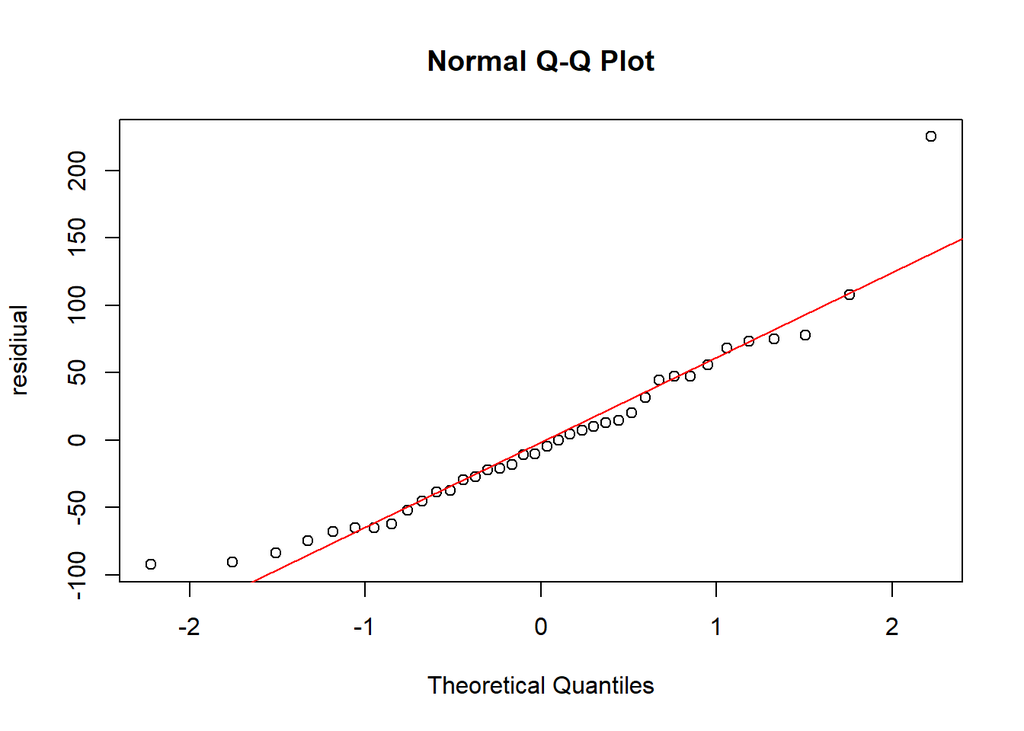

```r
qqnorm(residuals(model2),ylab = "residiual")
qqline(residuals(model2),col="red")
```

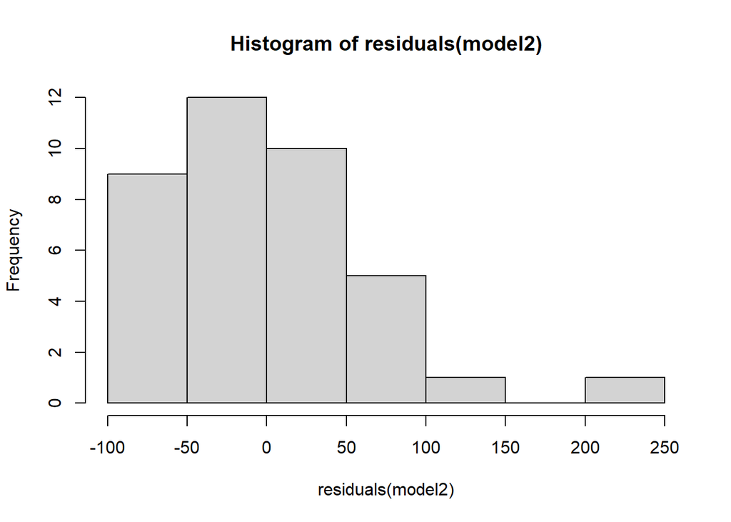

```r
hist(residuals(model2))
```

Birde shapiro.test ile Kontrol edelim;

```r
shapiro.test(residuals(model2))
```

```
##
##  Shapiro-Wilk normality test
##
## data:  residuals(model2)
## W = 0.92802, p-value = 0.01738
```

H0: normality var H1: normality yok

Testin sonucuna göre p-value değeri 0.017 geldi. Yani 0.05 den küçük olduğu için H0 reddedilir. Bunun sonucunda hataların normal dağılımı varsayımı sağlanmıyor.

Histograma ve qq grafiğine baktığımız zaman birkaç tane yüksek değerli aykırı gözlem var. Belki bundan dolayı modelin normalitesi bozuluyor olabilir. Aykırı gözlemleri çıkartıp tekrar bir model kurup bu modeli inceleyelim.

## Aykırı Değer Analizi

```r
standardized_residuals <- rstandard(model2)
summary(standardized_residuals)
```

```
##      Min.   1st Qu.    Median      Mean   3rd Qu.      Max.
## -1.516979 -0.688732 -0.119536  0.003307  0.657046  3.547406
```

Cook’s Distance Öncelikle distance değerlerini bulup daha sonra hangi noktadan itibaren aykırı değer olarak alacağımızı belirleyelim

```r
dist<-cooks.distance(model2)
olcut1<- mean(dist)*3
olcut2<-4/length(dist)
olcut1;olcut2
```

```
## [1] 0.09418927
```

```
## [1] 0.1052632
```

```r
olcut1Index<-which(dist>olcut1)
olcut2Index<-which(dist>olcut2)
length(olcut1Index)
```

```
## [1] 4
```

```r
length(olcut2Index)
```

```
## [1] 3
```

ölçüt1’e göre 4 aykırı değer, ölçüt2’ye göre 3 aykırı değer vardır. Verimizin boyutu çok büyük olmadığından dolayı ölçüt2 ile yolumuza devam edelim.

Görsel olarak inclemek istersek;

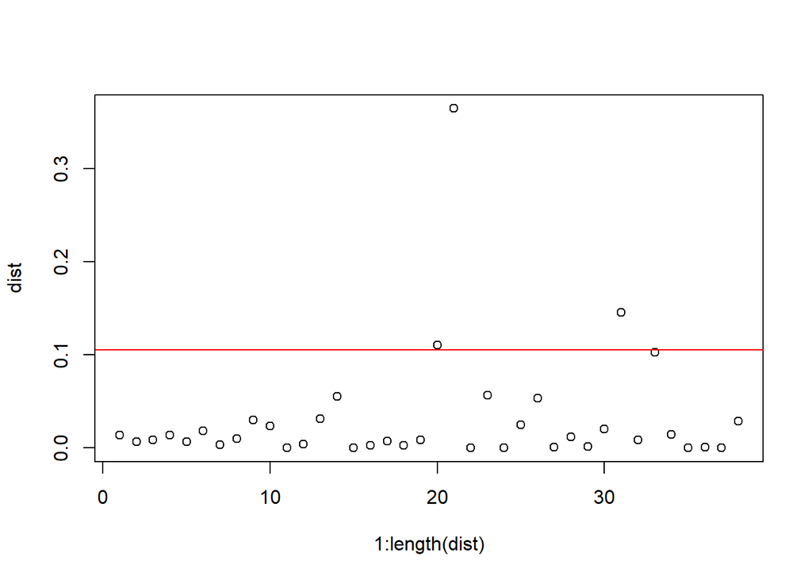

```r
plot(1:length(dist),dist,type='p',ylim=range(dist)*c(1,1))
abline(h=olcut2,col='red')
```

Aykırı Değerler tespit ettik. Şimdi bunları trainset içerisinden çıkartarak yeni trainset’imizi elde edelim

```r
outliers <- which(dist>olcut2 &
  abs(standardized_residuals)>2)
trainsetrem <- train[-outliers,]
nrow(train); nrow(trainsetrem)
```

```
## [1] 38
```

```
## [1] 37
```

## Aykırıları çıkardıktan sonra tekrar model kuralım

```r
names(trainsetrem)
```

```
## [1] "Petrol_tax"                   "Average_income"
## [3] "Paved_Highways"               "Population_Driver_licence..."
## [5] "Petrol_Consumption"
```

```r
model2rem<- lm(Petrol_Consumption~.-Paved_Highways,data = trainsetrem)
summary(model2rem)
```

```
##
## Call:
## lm(formula = Petrol_Consumption ~ . - Paved_Highways, data = trainsetrem)
##
## Residuals:
##     Min      1Q  Median      3Q     Max
## -76.868 -38.482  -4.785  27.743 113.033
##
## Coefficients:
##                                Estimate Std. Error t value Pr(>|t|)
## (Intercept)                   430.00646  137.54367   3.126  0.00368 **
## Petrol_tax                    -28.91524    9.17560  -3.151  0.00345 **
## Average_income                 -0.07401    0.01603  -4.618 5.66e-05 ***
## Population_Driver_licence... 1206.37796  162.18834   7.438 1.51e-08 ***
## ---
## Signif. codes:  0 '***' 0.001 '**' 0.01 '*' 0.05 '.' 0.1 ' ' 1
##
## Residual standard error: 54.02 on 33 degrees of freedom
## Multiple R-squared:  0.753,  Adjusted R-squared:  0.7306
## F-statistic: 33.54 on 3 and 33 DF,  p-value: 3.912e-10
```

Aykırıları Çıkardıktan sonra kurduğumuz model2rem, p-value değerine baktığımız zaman model anlamlı gelmiştir. $R^2$=0.7306 olmuştur. Yani aykırıları çıkardıktan sonra modelin $R^2$ değeri artmıştır. Bağımsız değişkenler önceki modeldeki gibi anlamlı gelmiştir.

Birde yeni elde ettiğimiz model2rem’i bir önceki model2 ile test üzerinden karşılaştıralım.

```r
prediction2<- predict(model2,test)
prediction3<- predict(model2rem,test)
```

```r
karsilastirma <- data.frame("R2"=c(R2(prediction2, test$Petrol_Consumption),R2(prediction3, test$Petrol_Consumption)),
                            "RMSE"=c(RMSE(prediction2, test$Petrol_Consumption),RMSE(prediction3, test$Petrol_Consumption)),
                            "MAE"=c(MAE(prediction2, test$Petrol_Consumption),MAE(prediction3, test$Petrol_Consumption)),
                            "AIC"=c(AIC(model2, k = 5),AIC(model2rem, k = 5)),
                            "BIC"=c(BIC(model2),BIC(model2rem)))
row.names(karsilastirma)<- c("model2","model2rem")
karsilastirma
```

```
##                  R2     RMSE      MAE      AIC      BIC
## model2    0.6487435 68.07854 58.55065 448.2392 441.4271
## model2rem 0.6524140 62.13790 53.16330 420.9856 414.0402
```

Modelleri test üzerinden karşılaştırdığımız zaman aykırıların çıkarıldığı modelin gözle görülür bir şekilde performansının artığını söyleyebiliriz.

Şimdi en son elde ettiğimiz modelin varsayımlarını kontrol edelim.

# Yeni Modelin Varsayım Kontrolü

## Değişen Varyans Kontrolü

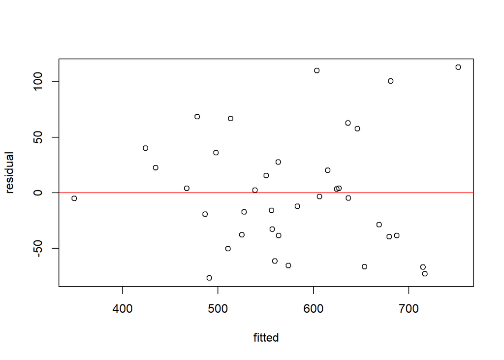

```r
plot(model2rem$fitted.values,model2rem$residuals,
     xlab = "fitted",ylab = "residual")
abline(h=0,col="red")
```

Grafiği incelediğimiz zaman değişen varyans durumu yok gibi gözüküyor. Birde Breusch-Pagan testi ile kontrol edelim.

```r
bptest(model2rem,data=petrol)
```

```
##
##  studentized Breusch-Pagan test
##
## data:  model2rem
## BP = 7.7492, df = 3, p-value = 0.05149
```

H0: hatalarin varyansi sabit H1: hatalarin varyansi sabit degil

p-value 0.05149 yani 0.05 değerinden büyük fakat sınıra çok yakın. Değişken dönüşümü uygularsak daha iyi hale gelir mi? inceleyelim.

## Değişken dönüşümü uygularak yeni bir model elde edelim

```r
model2rem1<-lm(log(Petrol_Consumption)~.-Paved_Highways,data = trainsetrem)
summary(model2rem1)
```

```
##
## Call:
## lm(formula = log(Petrol_Consumption) ~ . - Paved_Highways, data = trainsetrem)
##
## Residuals:
##       Min        1Q    Median        3Q       Max
## -0.152255 -0.062322 -0.001466  0.054857  0.172172
##
## Coefficients:
##                                Estimate Std. Error t value Pr(>|t|)
## (Intercept)                   6.147e+00  2.260e-01  27.202  < 2e-16 ***
## Petrol_tax                   -4.714e-02  1.508e-02  -3.127  0.00368 **
## Average_income               -1.508e-04  2.634e-05  -5.727 2.15e-06 ***
## Population_Driver_licence...  2.115e+00  2.665e-01   7.937 3.74e-09 ***
## ---
## Signif. codes:  0 '***' 0.001 '**' 0.01 '*' 0.05 '.' 0.1 ' ' 1
##
## Residual standard error: 0.08876 on 33 degrees of freedom
## Multiple R-squared:  0.7828, Adjusted R-squared:  0.763
## F-statistic: 39.64 on 3 and 33 DF,  p-value: 4.791e-11
```

Değişken dönüşümü yapılmış model2rem1 modelini incelediğimizde, p-value değeri 0.05’den küçük yani model anlamlıdır. Bunun yanında $R^2$=0.76 gelmektedir. Bu $R^2$ değeri en son kullandığımız modelinkinden biraz daha yüksektir.

Değişken dönüşümü uyguladığımız son modeli (model2rem1), bir önceki model ile (model2rem) test üzerinden karşılaştıralım.

```r
prediction3<- predict(model2rem,test)
prediction4<- predict(model2rem1,test)

rmse_original <- sqrt(mean((test$Petrol_Consumption - exp(prediction4))^2))
mae_original <- mean(abs(test$Petrol_Consumption - exp(prediction4)))
```

```r
karsilastirma <- data.frame("R2"=c(R2(prediction3, test$Petrol_Consumption),R2(prediction4, test$Petrol_Consumption)),
                            "RMSE"=c(RMSE(prediction3, test$Petrol_Consumption),rmse_original),
                            "MAE"=c(MAE(prediction3, test$Petrol_Consumption),mae_original))
row.names(karsilastirma)<- c("model2rem","model2rem1")
karsilastirma
```

```
##                   R2     RMSE      MAE
## model2rem  0.6524140 62.13790 53.16330
## model2rem1 0.6522654 60.93629 51.43532
```

Modelleri karşılaştırdığımızda Değişken dönüşümü yaptığımız model, dönüşüm yapılmamış halinden daha iyi performans veriyor. Sonuç olarak şuan elimizdeki en iyi sonuç veren model; Paved_Highways değişkeninin çıkarılmış, aykırı gözlemlerden arındırılmış ve bağımlı değişkene değişken dönüşümü yapılmış modeldir.

Şimdi Bu model üzerinden tekrardan varsayım kontrolüne geçelim.

# “Model2rem1” modeli üzerinden Varsayım Kontrolü

## Değişen Varyans Kontrolü

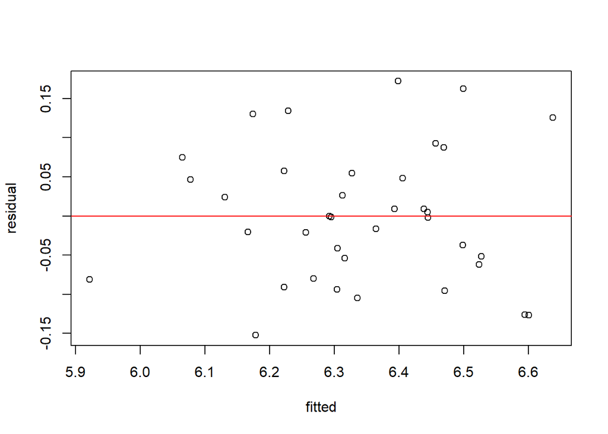

```r
plot(model2rem1$fitted.values,model2rem1$residuals,
     xlab = "fitted",ylab = "residual")
abline(h=0,col="red")
```

Grafik üzerinden incelediğimiz zaman değişen varyans durumu yok gibi duruyor. Birde Breusch-Pagan testini kullanalım

```r
bptest(model2rem1,data = petrol)
```

```
##
##  studentized Breusch-Pagan test
##
## data:  model2rem1
## BP = 2.2999, df = 3, p-value = 0.5125
```

H0: hatalarin varyansi sabit H1: hatalarin varyansi sabit degil

## Hataların Normal dağılımı

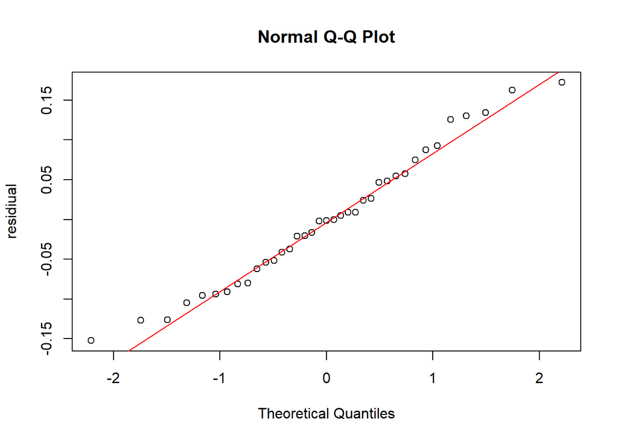

```r
qqnorm(residuals(model2rem1),ylab = "residiual")
qqline(residuals(model2rem1),col="red")
```

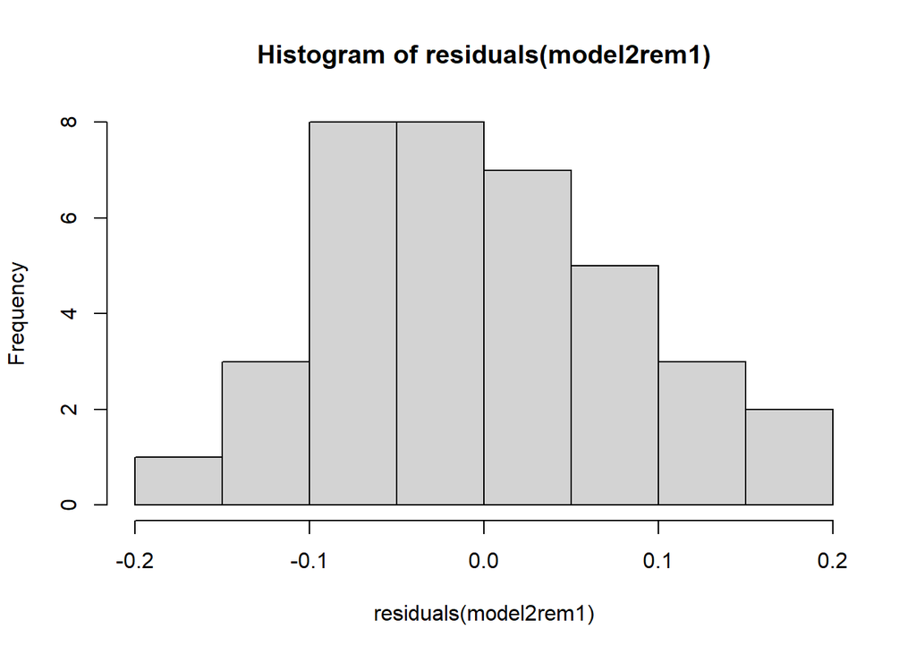

```r
hist(residuals(model2rem1))
```

Grafiği ve histogramı incelediğimizde normal dağılım varsayımı sağlanıyor gibi gözüküyor. Birde shapiro.test ile bu durumu Kontrol edelim;

```r
shapiro.test(residuals(model2rem1))
```

```
##
##  Shapiro-Wilk normality test
##
## data:  residuals(model2rem1)
## W = 0.97533, p-value = 0.5707
```

H0: normality var H1: normality yok

## Hataların ilişkisiz olması durumu kontrolu

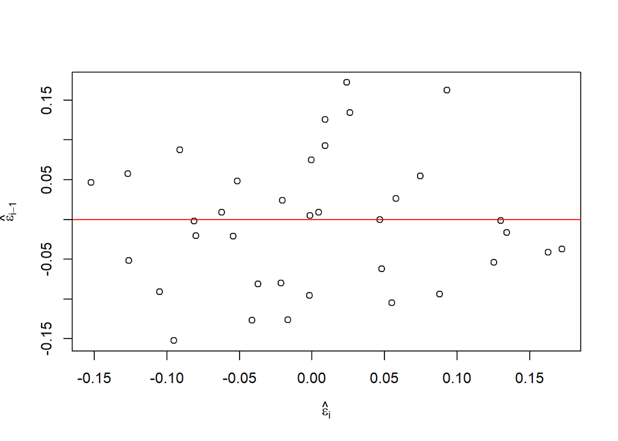

```r
n<- length(residuals(model2rem1))
plot(tail(residuals(model2rem1),n-1),head(residuals(model2rem1),n-1),
     xlab = expression(hat(epsilon)[i]),ylab=expression(hat(epsilon)[i-1]))
abline(h=0,col="red")
```

Grafik üzerinden yorumlarsak hataların herhangi bir ilişkisi gözükmüyordur. Bu yorumu desteklemek için Durbin-Watson testi ile inceleyelim;

```r
dwtest(model2rem1,data = petrol)
```

```
##
##  Durbin-Watson test
##
## data:  model2rem1
## DW = 1.8184, p-value = 0.2585
## alternative hypothesis: true autocorrelation is greater than 0
```

H0: hatalar araindaki otokorelasyon=0 yani hatalar iliskisiz H1: hatalar arasindaki otokorelasyon!=0 yani hatalar ilişkili

DW 2’ye yakınsa otokorelasyon yok (ilişki yok) DW > 2 negatif otokorelasyon DW < 2 pozitif otokorelasyon

p-value değerine ve dw değerine baktığımız zaman hataların birbiriyle ilişkisiz olduğunu söyleyebiliriz.

## multicolinearity Kontrolü

Öncelikle bağımsız değişkenler arasındaki korelasyonlara bakarak bir fikir edinelim

```r
modelData<-petrol[c("Petrol_tax","Average_income","Population_Driver_licence...","Petrol_Consumption")]
cor(modelData)
```

```
##                               Petrol_tax Average_income
## Petrol_tax                    1.00000000     0.01266516
## Average_income                0.01266516     1.00000000
## Population_Driver_licence... -0.28803717     0.15707008
## Petrol_Consumption           -0.45128028    -0.24486207
##                              Population_Driver_licence... Petrol_Consumption
## Petrol_tax                                     -0.2880372         -0.4512803
## Average_income                                  0.1570701         -0.2448621
## Population_Driver_licence...                    1.0000000          0.6989654
## Petrol_Consumption                              0.6989654          1.0000000
```

Korelasyonları incelediğimizde göze batan yüksek korelasyon değeri gözükmemektedir. Birde vif değerleri üzerinden inceleyelim;

```r
vif(model2rem1)
```

```
##                   Petrol_tax               Average_income
##                     1.094055                     1.030422
## Population_Driver_licence...
##                     1.108769
```

Bütün vif değerleri 10’dan küçüktür. Sonuç olarak herhangi bir multicolinearity problemi yoktur.

## NİHAİ SONUÇ

Sonuç olarak Petrol_Consumption verimizin Nihai modeli olarak Model2rem1 yani Paved_Highway değişkeni çıkartılmış, Aykırı değerlerden arındırılmış ve bağımlı değişkenimize değişken dönüşümü uygulanmış modele karar verdik.